# bike-data-analysis

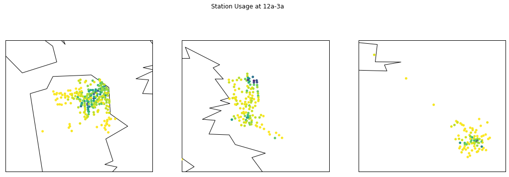

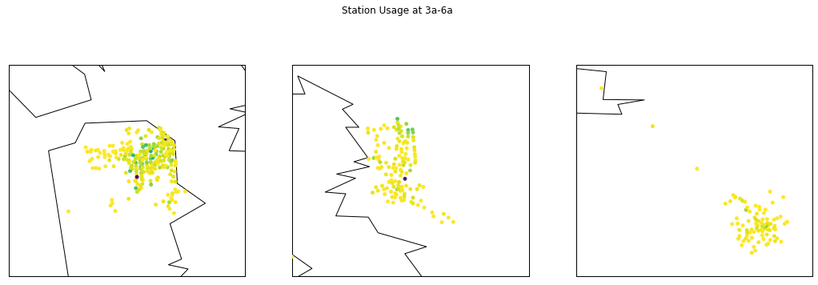

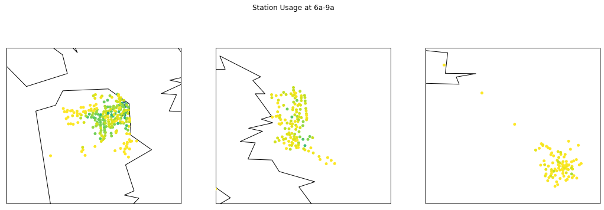

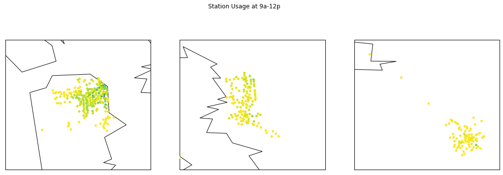

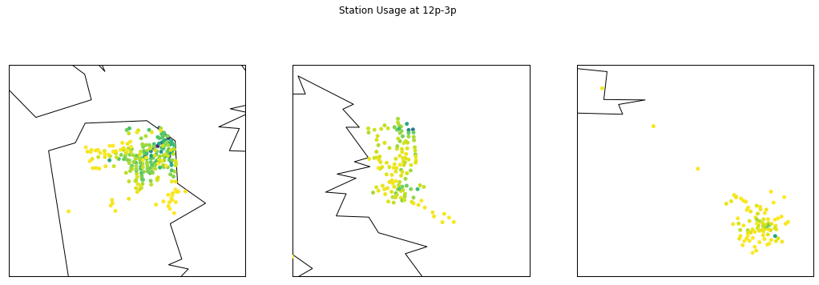

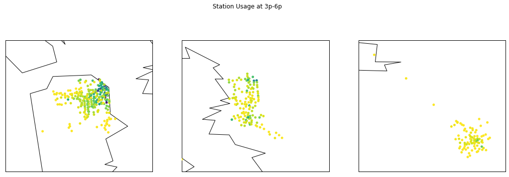

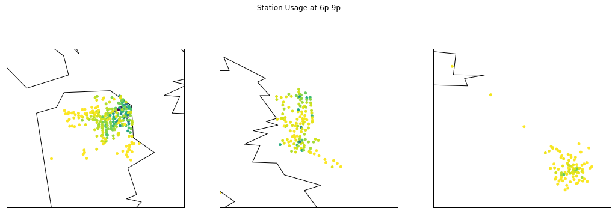

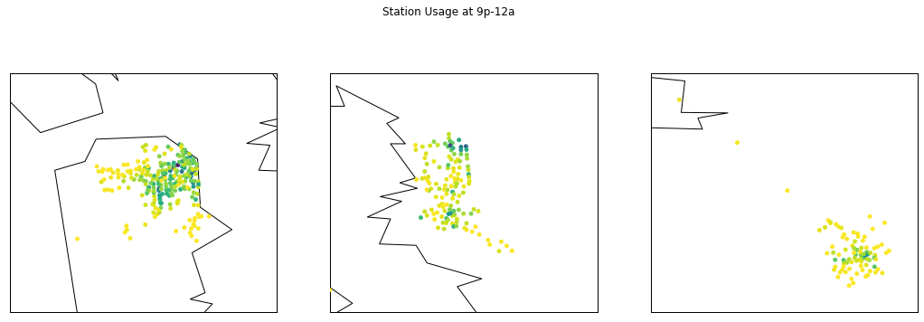

```python
for inter in time_intervals:
    fig = plt.figure(figsize = (18,6))
    plt.suptitle('Station Usage at ' + inter)

    for i in range(3):
        ax = fig.add_subplot(1, 3, i + 1)
        city_map = map_plot(cities[i][0], res = 'i')
        city_map.scatter(station_df['station_longitude'], station_df['station_latitude'], c = station_df[inter],
                  latlon = True, zorder = 10, s = 15, cmap = 'viridis_r')
    plt.show()
```

There are definitly differences in the station usage over time. Now I'm going to create those maps one a single scale so we can see the differences over time.

```python
#so I have a value for everything I'm changing zero to zeros in the log column, this will be slightly off,
#but really not enough to show a visual difference.
def log_and_zero(count):
    if count == 0:
        return 0
    else:
        return np.log10(count)

max_time_count_log = np.log10(station_df[time_intervals].max().max())
max_time_count_log
for i in time_intervals:
    station_df[i + '_log'] = station_df[i].apply(log_and_zero)

station_df.head()
```

|  | station_id | station_name | station_latitude | station_longitude | count | 12a-3a | 3a-6a | 6a-9a | 9a-12p | 12p-3p | ... | 6p-9p | 9p-12a | 12a-3a_log | 3a-6a_log | 6a-9a_log | 9a-12p_log | 12p-3p_log | 3p-6p_log | 6p-9p_log | 9p-12a_log |
| --- | --- | --- | --- | --- | --- | --- | --- | --- | --- | --- | --- | --- | --- | --- | --- | --- | --- | --- | --- | --- | --- |
| 0 | 36 | Folsom St at 3rd St | 37.783830 | -122.398870 | 13095 | 100 | 32 | 757 | 1680 | 1135 | ... | 2380 | 700 | 2.000000 | 1.505150 | 2.879096 | 3.225309 | 3.054996 | 3.178689 | 3.376577 | 2.845098 |
| 1 | 139 | Garfield Square (25th St at Harrison St) | 37.751017 | -122.411901 | 9678 | 38 | 10 | 1076 | 1720 | 799 | ... | 1042 | 290 | 1.579784 | 1.000000 | 3.031812 | 3.235528 | 2.902547 | 2.903633 | 3.017868 | 2.462398 |
| 2 | 155 | Emeryville Public Market | 37.840521 | -122.293528 | 2360 | 19 | 48 | 87 | 218 | 314 | ... | 404 | 135 | 1.278754 | 1.681241 | 1.939519 | 2.338456 | 2.496930 | 2.587711 | 2.606381 | 2.130334 |
| 3 | 41 | Golden Gate Ave at Polk St | 37.781270 | -122.418740 | 8603 | 68 | 32 | 412 | 1490 | 1053 | ... | 1008 | 255 | 1.832509 | 1.505150 | 2.614897 | 3.173186 | 3.022428 | 3.040998 | 3.003461 | 2.406540 |
| 4 | 339 | Jackson St at 11th St | 37.800002 | -122.266438 | 1980 | 62 | 2 | 196 | 167 | 186 | ... | 275 | 80 | 1.792392 | 0.301030 | 2.292256 | 2.222716 | 2.269513 | 2.450249 | 2.439333 | 1.903090 |

5 rows × 21 columns

```python
# Need a maximun so everythings on the same scale.
max_log = np.log10(station_df[time_intervals].max().max())
max_log
```

```
4.065990289233776
```

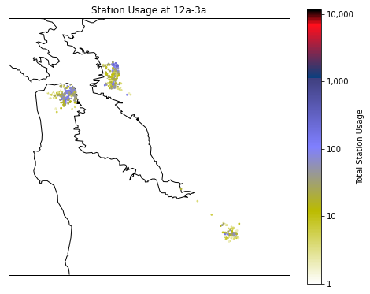

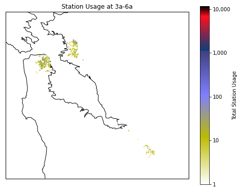

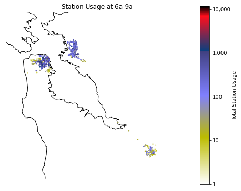

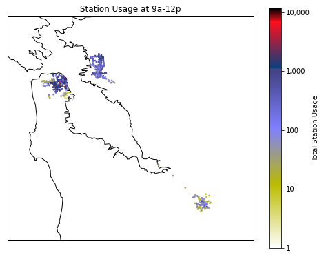

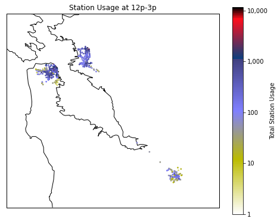

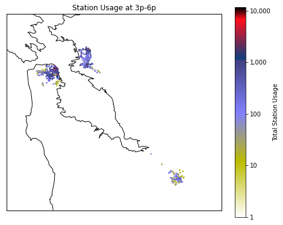

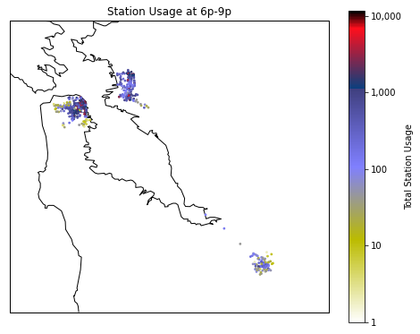

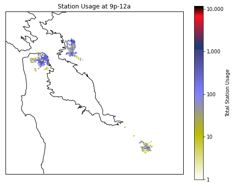

```python
for i in range(8):
    plt.figure(figsize = (8,8))
    bay_map = map_plot(bay_coord, res = 'h')
    bay_map.scatter(station_df['station_longitude'], station_df['station_latitude'],
                    c = station_df[time_intervals[i] + '_log'], latlon = True,
                    zorder = 10, s = 3, cmap = 'gist_stern_r', vmax = max_log)
    plt.title('Station Usage at ' + time_intervals[i])
    cb = plt.colorbar(label = 'Total Station Usage', shrink = 0.8)
    cb.set_ticks([0, 1, 2, 3, 4])
    cb.set_ticklabels(['1', '10', '100', '1,000', '10,000'])
    plt.savefig('bay_' + time_intervals[i] + '.png')
    plt.show();
```

Log doesn't look too good, let's see if it shows well without a log scale.

```python
max_usage = station_df[time_intervals].max().max()
max_usage
```

```
11641
```

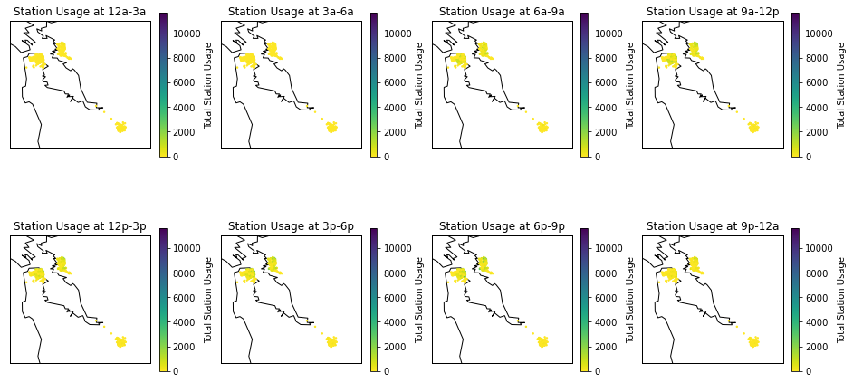

```python
plt.figure(figsize = (16,8))
for i in range(8):
    plt.subplot(2, 4, i+1)
    bay_map = map_plot(bay_coord, res = 'i')
    bay_map.scatter(station_df['station_longitude'], station_df['station_latitude'],
                    c = station_df[time_intervals[i]], latlon = True,
                    zorder = 10, s = 2, cmap = 'viridis_r', vmax = max_usage)
    plt.title('Station Usage at ' + time_intervals[i])
    plt.colorbar(label = 'Total Station Usage', shrink = 0.8)
```

Okay, the log scale seems to be better visually.

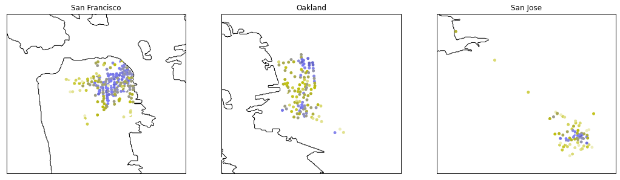

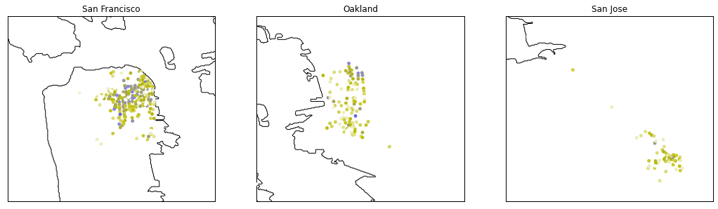

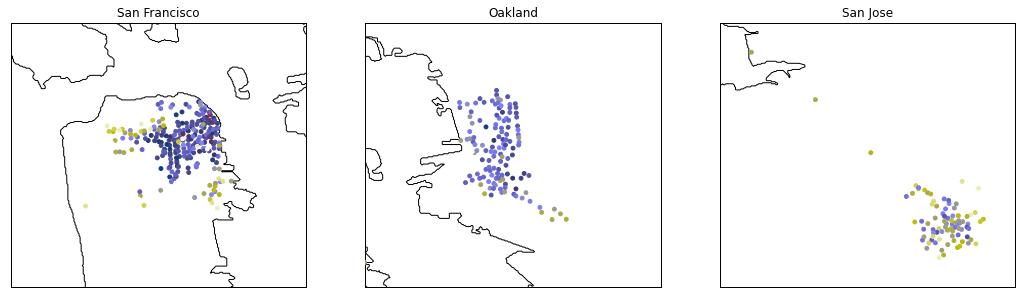

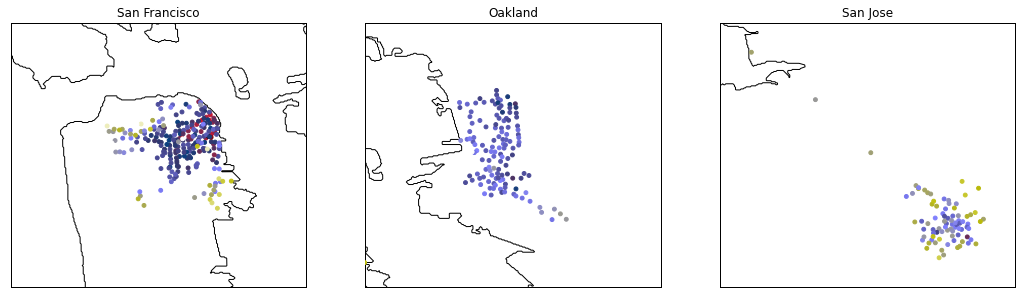

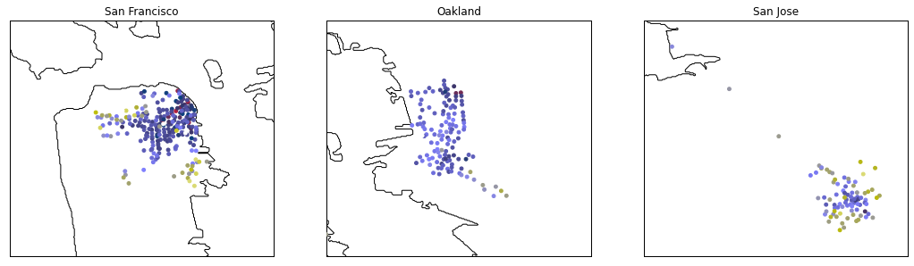

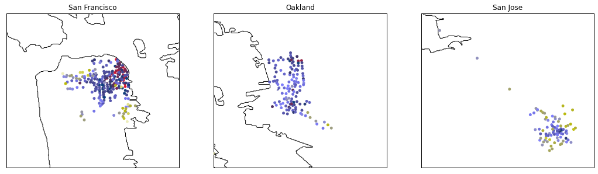

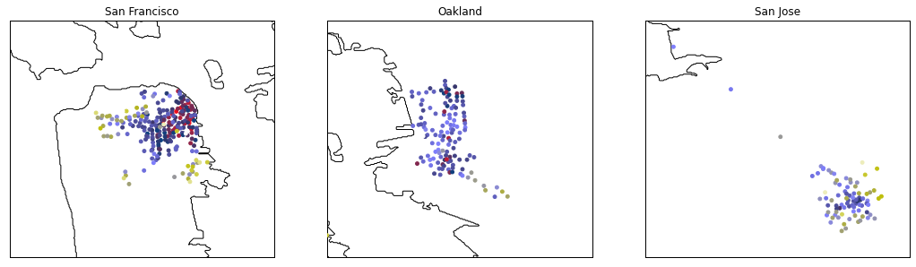

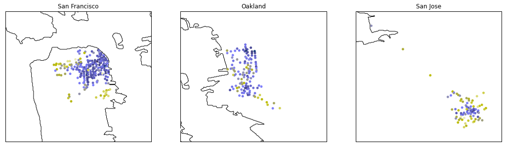

```python
for i in range(8):
    fig = plt.figure(figsize = (18,6))
    for j in range(3):
        ax = fig.add_subplot(1, 3, j + 1)
        city_map = map_plot(cities[j][0], res = 'f')
        city_map.scatter(station_df['station_longitude'], station_df['station_latitude'],
                         c = station_df[time_intervals[i] + '_log'], latlon = True,
                         zorder = 10, s = 15, cmap = 'gist_stern_r', vmax = max_log)
        plt.title(cities[j][1])
    plt.savefig('city_' + time_intervals[i] + '.png')
    plt.show()
```

There is definitly interesting. The color pallet was chosen so that there was distinction at the high end, not the greatest but seems to work.

### Distance between Start and Stop

I would like to see the distance of each ride. Unfortunately, the data did not previde this. The best I can do is determine the distance between the start and stop location for each ride.

The formula for the distance between to points on a sphere is d = r *arccos(sin(lat1)* sin(lat2) + cos(lat1) *cos(lat2)* cos(lon2 - lon1)). Of course the arccos needs to give the radians, so everything needs to be changed to radians. We're going to need a function for this.

```python
def dist_globe (lat1, lon1, lat2, lon2):
    r = 3963 #radius of earth in miles
    lat1r = math.radians(lat1)
    lon1r = math.radians(lon1)
    lat2r = math.radians(lat2)
    lon2r = math.radians(lon2)

    a = math.sin(lat1r) * math.sin(lat2r) + math.cos(lat1r) * math.cos(lat2r) * math.cos(lon2r - lon1r)
    #There are some round off errors here getting larger than 1
    if a > 1:
        a = 1
    d = r * math.acos(a)
    return d

bike_df['distance'] = bike_df.apply(lambda x: dist_globe(x['start_station_latitude'],
                                                         x['start_station_longitude'],
                                                         x['end_station_latitude'],
                                                         x['end_station_longitude']),
                                   axis = 1)
bike_df.head()
```

|  | duration_sec | start_time | end_time | start_station_id | start_station_name | start_station_latitude | start_station_longitude | end_station_id | end_station_name | end_station_latitude | end_station_longitude | bike_id | user_type | distance |
| --- | --- | --- | --- | --- | --- | --- | --- | --- | --- | --- | --- | --- | --- | --- |
| 0 | 85457 | 2019-07-31 09:25:37.341 | 2019-08-01 09:09:54.600 | 36 | Folsom St at 3rd St | 37.783830 | -122.398870 | 344 | 16th St Depot | 37.766349 | -122.396292 | 3491 | Customer | 1.217302 |
| 1 | 53831 | 2019-07-31 18:00:10.294 | 2019-08-01 08:57:21.975 | 139 | Garfield Square (25th St at Harrison St) | 37.751017 | -122.411901 | 133 | Valencia St at 22nd St | 37.755213 | -122.420975 | 2457 | Customer | 0.574875 |
| 2 | 33674 | 2019-07-31 22:52:29.791 | 2019-08-01 08:13:44.010 | 155 | Emeryville Public Market | 37.840521 | -122.293528 | 155 | Emeryville Public Market | 37.840521 | -122.293528 | 2750 | Customer | 0.000000 |
| 3 | 34546 | 2019-07-31 21:59:34.258 | 2019-08-01 07:35:21.044 | 41 | Golden Gate Ave at Polk St | 37.781270 | -122.418740 | 73 | Pierce St at Haight St | 37.771793 | -122.433708 | 303 | Subscriber | 1.048477 |
| 4 | 40244 | 2019-07-31 20:20:37.542 | 2019-08-01 07:31:21.606 | 339 | Jackson St at 11th St | 37.800002 | -122.266438 | 233 | 4th Ave at E 12th St (Temporary Location) | 37.795913 | -122.255547 | 2637 | Subscriber | 0.659017 |

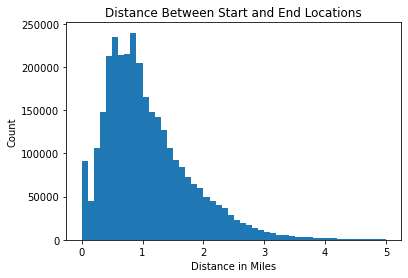

```python
plt.hist(bike_df['distance'], bins = 50, range = (0, 5));
plt.title('Distance Between Start and End Locations')
plt.xlabel('Distance in Miles')
plt.ylabel('Count')
```

```python
bike_df[bike_df['distance'] > 5]['distance'].count(), bike_df['distance'].max()
```

```
(6362, 43.278180106088094)
```

The majority of bikes end up within 1.5 miles of their start. The farthest a bike went from start to stop was 43.3 miles.

## BART Data

I would like to look at how Bay Wheels work in conjunction with the BART system (Bay Area Rapid Transit). First, I'm just going to graph the routes along with the popularity of the stations. Then I plan to find the distance from the bike station to the nearest BART station and see how this coorelates.

```python
# Loading up the list of BART stations and the routes
path = '/kaggle/input/bikedata/BART/'

bart_df = pd.read_csv(path + 'bart.csv')
# Ordered in the same order as in the 2019 schedule
bart_yellow_df = pd.read_csv(path + 'bart_yellow.csv')
bart_green_df = pd.read_csv(path + 'bart_green.csv')
bart_red_df = pd.read_csv(path + 'bart_red.csv')
bart_orange_df = pd.read_csv(path + 'bart_orange.csv')
bart_blue_df = pd.read_csv(path + 'bart_blue.csv')

bart_df.head()
```

|  | name | abbriviation | latitude | longitude |
| --- | --- | --- | --- | --- |
| 0 | 12th St. Oakland City Center | 12TH | 37.803768 | -122.271450 |
| 1 | 16th St. Mission | 16TH | 37.765062 | -122.419694 |
| 2 | 19th St. Oakland | 19TH | 37.808350 | -122.268602 |
| 3 | 24th St. Mission | 24TH | 37.752470 | -122.418143 |
| 4 | Antioch | ANTC | 37.995388 | -121.780420 |

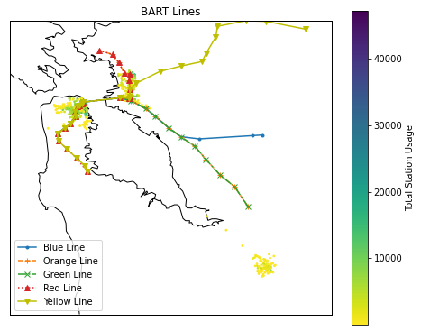

```python
plt.figure(figsize = (8,8))
bay_map = map_plot(bay_coord, res = 'h')
bay_map.scatter(station_df['station_longitude'], station_df['station_latitude'], c = station_df['count'],
          latlon = True, zorder = 2, s = 3, cmap = 'viridis_r')
bay_map.plot(bart_blue_df['longitude'], bart_blue_df['latitude'], '.-', label = 'Blue Line')
bay_map.plot(bart_orange_df['longitude'], bart_orange_df['latitude'], '+--', label = 'Orange Line')
bay_map.plot(bart_green_df['longitude'], bart_green_df['latitude'], 'x-.', label = 'Green Line')
bay_map.plot(bart_red_df['longitude'], bart_red_df['latitude'], '^:', label = 'Red Line')
bay_map.plot(bart_yellow_df['longitude'], bart_yellow_df['latitude'], 'vy-', label = 'Yellow Line')
plt.title('BART Lines')
plt.legend()
plt.colorbar(label = 'Total Station Usage', shrink = 0.8)
plt.savefig('bay_bart.png');
```

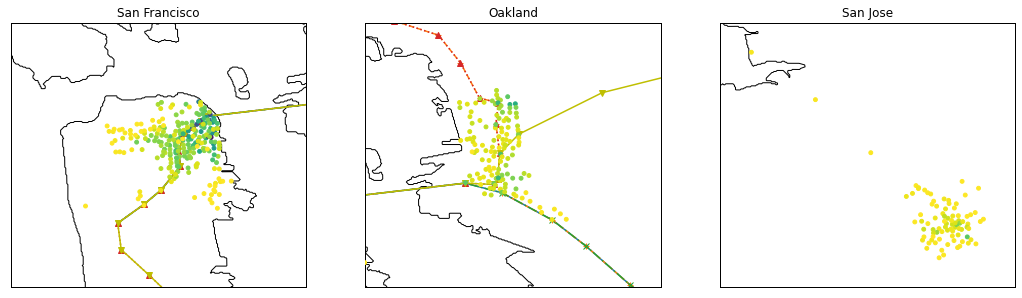

```python
fig = plt.figure(figsize = (18,6))

for i in range(3):
    ax = fig.add_subplot(1, 3, i + 1)
    city_map = map_plot(cities[i][0])
    city_map.scatter(station_df['station_longitude'], station_df['station_latitude'], c = station_df['count'],
              latlon = True, zorder = 10, s = 15, cmap = 'viridis_r')
    city_map.plot(bart_blue_df['longitude'], bart_blue_df['latitude'], '.-', label = 'Blue Line')
    city_map.plot(bart_orange_df['longitude'], bart_orange_df['latitude'], '+--', label = 'Orange Line')
    city_map.plot(bart_green_df['longitude'], bart_green_df['latitude'], 'x-.', label = 'Green Line')
    city_map.plot(bart_red_df['longitude'], bart_red_df['latitude'], '^:', label = 'Red Line')
    city_map.plot(bart_yellow_df['longitude'], bart_yellow_df['latitude'], 'vy-', label = 'Yellow Line')
    plt.title(cities[i][1])
plt.savefig('city_bart.png');
```

I didn't know that the BART didn't extend to San Jose. So for the rest of the analysis of Bay Wheels and BART, I'm going to remove San Jose from the list. Now let's find the distance from the bike station to the nearest BART station and see if there's any coorelation.

```python
sf_oak_stations = station_df[station_df['station_longitude'] <= -122.1]
sf_oak_stations.shape
```

```
(364, 21)
```

```python
def to_bart(lat, lon):
    min_dist = 100 #rediculously large so it will take the first value
    for i in bart_df.index:
        bart_lat = bart_df.loc[i, 'latitude']
        bart_lon = bart_df.loc[i, 'longitude']
        min_dist = min(min_dist, dist_globe(lat, lon, bart_lat, bart_lon))

    return min_dist

sf_oak_stations['bart_distance'] = sf_oak_stations.apply(lambda x: to_bart(x['station_latitude'],
                                                                           x['station_longitude']), axis = 1)
sf_oak_stations.head()
```

|  | station_id | station_name | station_latitude | station_longitude | count | 12a-3a | 3a-6a | 6a-9a | 9a-12p | 12p-3p | ... | 9p-12a | 12a-3a_log | 3a-6a_log | 6a-9a_log | 9a-12p_log | 12p-3p_log | 3p-6p_log | 6p-9p_log | 9p-12a_log | bart_distance |
| --- | --- | --- | --- | --- | --- | --- | --- | --- | --- | --- | --- | --- | --- | --- | --- | --- | --- | --- | --- | --- | --- |
| 0 | 36 | Folsom St at 3rd St | 37.783830 | -122.398870 | 13095 | 100 | 32 | 757 | 1680 | 1135 | ... | 700 | 2.000000 | 1.505150 | 2.879096 | 3.225309 | 3.054996 | 3.178689 | 3.376577 | 2.845098 | 0.403860 |
| 1 | 139 | Garfield Square (25th St at Harrison St) | 37.751017 | -122.411901 | 9678 | 38 | 10 | 1076 | 1720 | 799 | ... | 290 | 1.579784 | 1.000000 | 3.031812 | 3.235528 | 2.902547 | 2.903633 | 3.017868 | 2.462398 | 0.355853 |
| 2 | 155 | Emeryville Public Market | 37.840521 | -122.293528 | 2360 | 19 | 48 | 87 | 218 | 314 | ... | 135 | 1.278754 | 1.681241 | 1.939519 | 2.338456 | 2.496930 | 2.587711 | 2.606381 | 2.130334 | 1.537650 |
| 3 | 41 | Golden Gate Ave at Polk St | 37.781270 | -122.418740 | 8603 | 68 | 32 | 412 | 1490 | 1053 | ... | 255 | 1.832509 | 1.505150 | 2.614897 | 3.173186 | 3.022428 | 3.040998 | 3.003461 | 2.406540 | 0.273901 |
| 4 | 339 | Jackson St at 11th St | 37.800002 | -122.266438 | 1980 | 62 | 2 | 196 | 167 | 186 | ... | 80 | 1.792392 | 0.301030 | 2.292256 | 2.222716 | 2.269513 | 2.450249 | 2.439333 | 1.903090 | 0.216956 |

5 rows × 22 columns

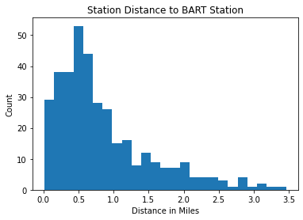

```python
plt.hist(sf_oak_stations['bart_distance'], bins = 25)
plt.title('Station Distance to BART Station')
plt.ylabel('Count')
plt.xlabel('Distance in Miles')
```

It does look like the majority of the bike stations are within 1 mile of a BART station. Now let's see if there's a cooralation between the popularity and distance.

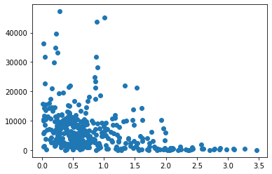

```python
plt.scatter(sf_oak_stations['bart_distance'], sf_oak_stations['count'])
```

Nothing conclusive. Let's try log on the y-axis.

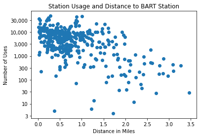

```python
plt.scatter(sf_oak_stations['bart_distance'], np.log10(sf_oak_stations['count']))
plt.title('Station Usage and Distance to BART Station')
plt.xlabel('Distance in Miles')
plt.ylabel('Number of Uses')
plt.yticks(ticks = [0.5, 1.0, 1.5, 2.0, 2.5, 3.0, 3.5, 4.0, 4.5],
           labels = ['3', '10', '30', '100', '300', '1,000', '3,000', '10,000', '30,000']);
plt.savefig('bart_usage.png');
```

There is a relationship, not the strongest, but it's there.